# Texas 2016 US Presidential Campaign Contribution Analysis

## by Patrick Bloomingdale

This project is part of Udacity’s Data Analyst Nanodegree  
**Term:** 2  
**Project:** 2  
**Due Date:** November 13, 2018

========================================================

## Introduction

For this project, I will conduct an exploratory data analysis (EDA) and create an RMD file that explores the variables, structure, patterns, oddities, and underlying relationships the following dataset:  
> [**2016 Presidential Campaign Finance Data**](https://classic.fec.gov/disclosurep/PDownload.do)

### Dataset Considerations

**CONTRIBUTION LIMITS**  
[**Contribution limits for 2015-2016**](https://www.fec.gov/updates/contribution-limits-for-2015-2016/)  
Under the Federal Election Campaign Act (the Act), the limits on contributions made by persons to candidates (increased to $2,700 per election, per candidate) (52 U.S.C. Â§ 30116(a)(1)(A)). The per-election limits on contributions to candidates are in effect for the two-year election cycle beginning the day after the general election and ending on the date of the next general election (November 5, 2014 - November 8, 2016). All other contribution limits are in effect for the two-calendar-year period beginning on January 1, 2015 and ending on December 31, 2016.

[**2016 PRESIDENTIAL ELECTION RESULTS FOR THE UNITED STATES**](https://www.270towin.com/2016_Election/)  
The United States presidential election of 2016 was held on Tuesday, November 8, 2016. The Republican canidate Donald Trump defeated the Democratic canidate Hillary Clinton.

The table below represents the results from the 2016 presidential election. The only canidates included in this table are the ones that received the parties nomination.

| Candidate | Party | Electoral Votes | Popular Votes |
| --- | --- | --- | --- |
| Donald J. Trump | Republican | 304 | 62,980,160 |
| Hillary R. Clinton | Democratic | 227 | 65,845,063 |
| Gary Johnson | Libertarian | 0 | 4,488,931 |
| Jill Stein | Green | 0 | 1,457,050 |
| Evan McMullin | Independent | 0 | 728,830 |

[**2016 PRESIDENTIAL ELECTION RESULTS FOR THE STATE OF TEXAS**](https://www.politico.com/2016-election/results/map/president/texas/)  
The table below represents Texas’ results from the 2016 presidential election. The only canidates included in this table are the ones that received the parties nomination.

| Candidate | Party | Popular Votes | Percentage |
| --- | --- | --- | --- |
| Donald J. Trump | Republican | 4,681,590 | 52.6 |
| Hillary R. Clinton | Democratic | 3,867,816 | 43.4 |
| Gary Johnson | Libertarian | 282,524 | 3.2 |
| Jill Stein | Green | 71,307 | 0.8 |
| Evan McMullin* | Independent | na | na |

*Dataset did not contain any votes for canidate

**Party Affiliation**  
To ensure I have the corrected canidate associated with the correct party, I downloaded a list of all the canidates with their party affiliation from the [Federal Election Commission](https://www.fec.gov/data/advanced/?tab=candidates) , then compared it to the list of canidate names to assign a party affiliation.

**Initial Exploratory Questions**  
1. Is there a relationship between campaign contributions and party affiliation?  
2. What is the total ammount of campaign contributions per canidate?  
3. Campaign contributions and gender?  
4. Campaign contributions and occupation?

**ADDITIONAL RESOURCES**  
[**Democratic Convention**](http://www.thegreenpapers.com/P16/D)  
[**Democratic Convention - Texas**](http://www.thegreenpapers.com/P16/TX-D#TX-D-STATEWIDE)  
[**Republican Convention**](http://www.thegreenpapers.com/P16/R)  
[**Republican Convention - Texas**](http://www.thegreenpapers.com/P16/TX-R#TX-R-STATEWIDE)

# Univariate Plots Section

```
## 'data.frame':    548396 obs. of  14 variables:
##  $ cand_id          : Factor w/ 25 levels "P00003392","P20002671",..: 1 23 23 12 1 1 23 23 1 23 ...
##  $ cand_nm          : Factor w/ 25 levels "Bush, Jeb","Carson, Benjamin S.",..: 4 23 23 20 4 4 23 23 4 23 ...
##  $ contbr_nm        : Factor w/ 129927 levels "'CALL, JANE",..: 78846 104629 104633 67432 47336 126503 99534 93791 58977 93812 ...
##  $ contbr_city      : Factor w/ 2252 levels "","-2111",". FREEPORT.       PAY FOR EMPL",..: 427 699 2200 1474 1802 116 1858 965 1918 1248 ...
##  $ contbr_st        : Factor w/ 1 level "TX": 1 1 1 1 1 1 1 1 1 1 ...
##  $ contbr_zip       : Factor w/ 66332 levels "","00000","000078043",..: 50059 18338 32877 19908 48359 57008 45708 32935 17812 17201 ...
##  $ contbr_employer  : Factor w/ 40164 levels "","'CALL PHONOGRAPH LLC",..: 24038 3596 28912 24933 6082 9778 17644 17644 8244 30753 ...
##  $ contbr_occupation: Factor w/ 17467 levels "","-"," CERTIFIED REGISTERED NURSE ANESTHETIS",..: 13568 13238 13568 10154 14388 14007 7704 7704 11436 7239 ...
##  $ contb_receipt_amt: num  37.1 127.1 80 15 50 ...
##  $ contb_receipt_dt : Factor w/ 746 levels "01-APR-15","01-APR-16",..: 359 681 6 132 191 72 701 725 484 91 ...
##  $ form_tp          : Factor w/ 3 levels "SA17A","SA18",..: 2 2 2 1 2 2 2 2 2 2 ...
##  $ file_num         : int  1091718 1146165 1146165 1077404 1091718 1091718 1146165 1146165 1091718 1146165 ...
##  $ tran_id          : Factor w/ 543825 levels "A0009C127D0D344E3885",..: 139500 461349 403810 493948 139256 139041 429428 400817 139706 461688 ...
##  $ election_tp      : Factor w/ 5 levels "","G2016","O2016",..: 5 2 2 5 5 5 2 2 5 2 ...
```

**FINDINGS**  
The dataset contains the following:  
- 548,396 observations (rows) and 14 variables (columns)  
- 25 Canidates  
- 129,927 Contributors

## 1. Contribution Amounts (Univariate)

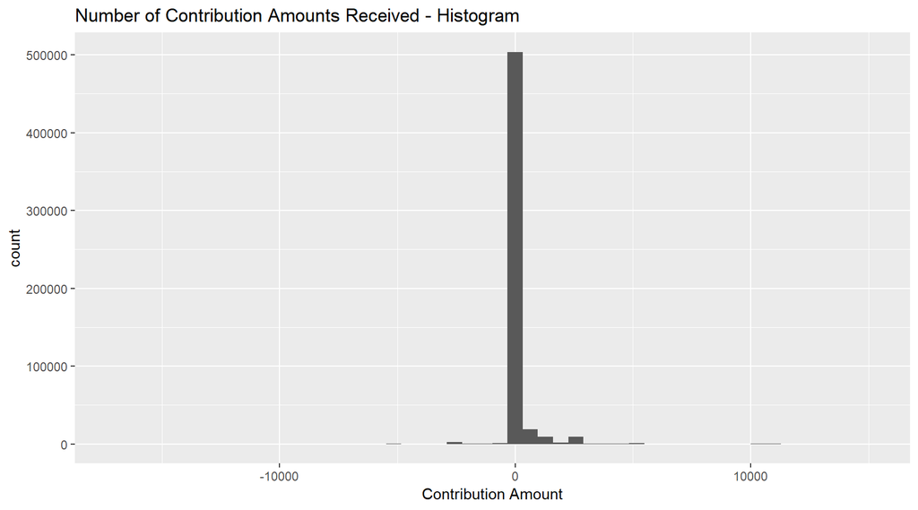

```
## [1] 12084
```

**FINDINGS**  
The histogram above shows that the dataset has negative contribution amounts. I am going to remove the 12,084 values less than zero to get a better idea of what the contributions look like. Then I am going to use a boxplot to look for any outliers.

```
## [1] 0
```

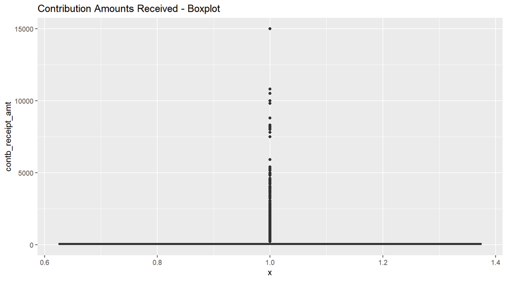

```
## [1] 10093
```

**FINDINGS**  
The boxplot above shows that their are lots of outliers making it hard to get a detailed analysis of the contributions. As stated earlier in the `Introduction` section, the maximum amount an individual can contribute is `$2,700`. I am going to remove the 10,093 contributions that are greater than the $2,700 because they should have been refunded.

```
## [1] 0
```

```
##    Min. 1st Qu.  Median    Mean 3rd Qu.    Max.
##    0.04   25.00   40.00  142.87  100.00 2700.00
```

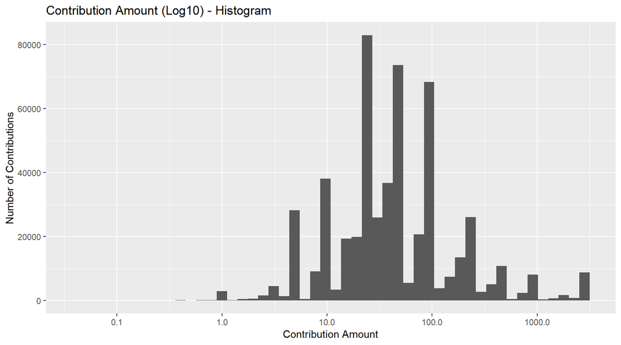

I have determined that I need to add more variables and clean up others to do a more detailed analysis.

## 2. Contributions to Party (Univariate)

```
## [1] 534657
```

```
## # A tibble: 3 x 5
##   party      sum_party number_of_candidate mean_party      n
##   <chr>          <dbl>               <int>      <dbl>  <int>
## 1 Democrat   26724636.                   5   5344927. 281600
## 2 Other        452654.                   3    150885.   1895
## 3 Republican 49208161.                  17   2894598. 251162
```

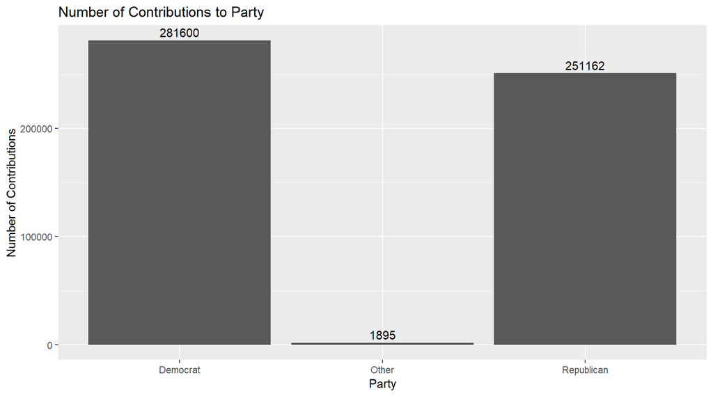

## 3. Contributions to Canidate (Univariate)

```
##
##                 Bush, Jeb       Carson, Benjamin S.
##                      3299                     23163
##  Christie, Christopher J.   Clinton, Hillary Rodham
##                       192                    201801
## Cruz, Rafael Edward 'Ted'            Fiorina, Carly
##                    131173                      2509
##      Gilmore, James S III        Graham, Lindsey O.
##                         5                       152
##            Huckabee, Mike             Jindal, Bobby
##                       709                        57
##             Johnson, Gary           Kasich, John R.
##                      1335                      1177
##          Lessig, Lawrence            McMullin, Evan
##                        32                       196
##   O'Malley, Martin Joseph         Pataki, George E.
##                       225                         9
##                Paul, Rand    Perry, James R. (Rick)
##                      3010                       562
##              Rubio, Marco          Sanders, Bernard
##                      8318                     79483
##      Santorum, Richard J.               Stein, Jill
##                       251                       364
##          Trump, Donald J.             Walker, Scott
##                     76128                       448
##     Webb, James Henry Jr.
##                        59
```

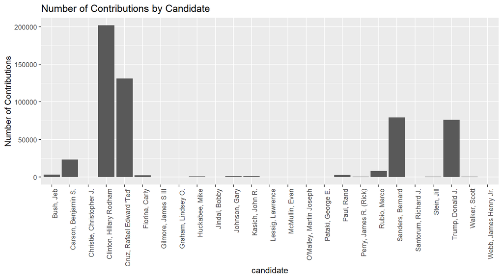

## 4. Contributions by Gender (Univariate)

```
## # A tibble: 2 x 3
##   gender   sum_gen  n_gen
##   <chr>      <dbl>  <int>
## 1 female 29100036. 243640
## 2 male   44105382. 274007
```

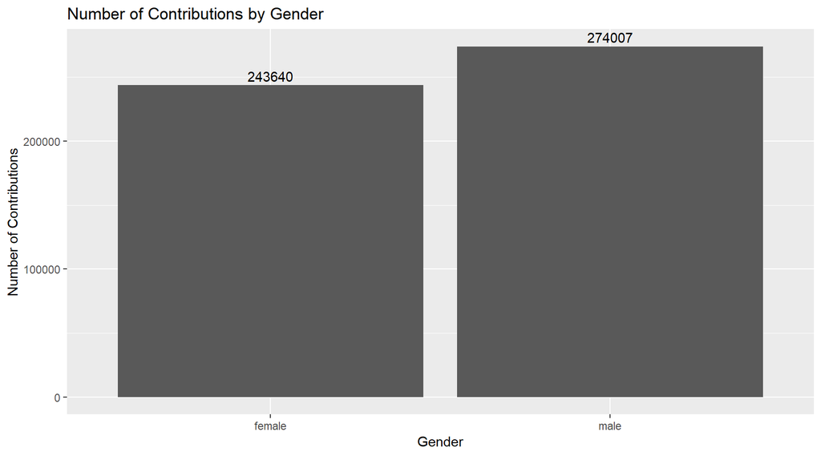

**FINDINGS**  
Of the total 517,647 contributions:  
- Females accounted for approximately 243,640 (47%) of contributions  
- Males accounted for approximately 274,007 (53%) of contributions

## 5. Contributions by Occupation (Univariate)

```
## # A tibble: 5 x 4
##   contbr_occupation  sum_occu mean_occu      n
##   <ord>                 <dbl>     <dbl>  <int>
## 1 RETIRED           14463581.     106.  135939
## 2 NOT EMPLOYED       1115696.      49.3  22635
## 3 ATTORNEY           3970684.     294.   13516
## 4 HOMEMAKER          3396749.     328.   10358
## 5 ENGINEER           1178076.     139.    8484
```

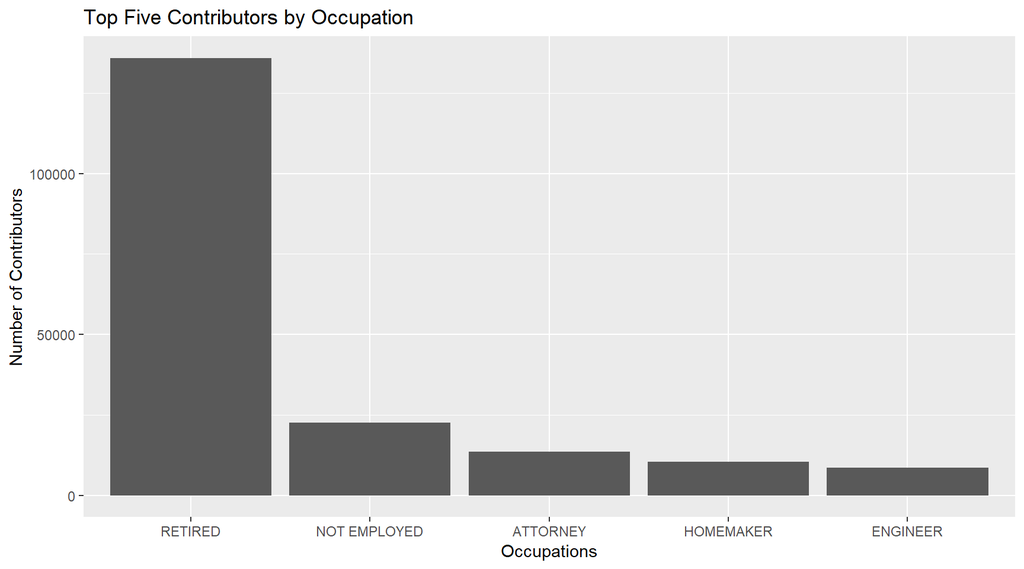

**FINDINGS**  
Since there were 16,992 different occupations listed in the data set I decided to only analyze the top five contributor occupations:  
- Retired at 135,939  
- Not Employed at 22,635  
- Attorney at 13,516  
- Homemaker at 10,358  
- Engineer at 8,484

# Univariate Analysis

### What is the structure of your dataset?

- 548,396 observations (rows) and 14 variables (columns)
- 25 Canidates
- 129,927 Contributors

### What is/are the main feature(s) of interest in your dataset?

The maid features of the dataset I am interested in are `contribution amounts`(contb_receipt_amt), the `contributor` (contbr_nm), and the `canidate` (cand_nm).

### What other features in the dataset do you think will help support your

### investigation into your feature(s) of interest?

Other features in the dataset that will help support my investigation include:  
- Total Number of Contributions to Party  
- Number of Contributions to Candidate  
- Number of Contributions by Gender  
- Top Occupations by Number of Contributors  
- Date Contributions were Made

### Did you create any new variables from existing variables in the dataset?

**I created the following variables for a more detailed analysis:**  
-`party:` candidate party affilliation (Democrat, Republican, Other)  
-`gender:` contributor gender (male, female)

### Of the features you investigated, were there any unusual distributions?

- There were 10,093 contributions that were greater than the contribution limit of $2,700 so I removed them.
- There were 12,084 contributions that were negative values so I removed them.

### Did you perform any operations on the data to tidy, adjust, or change the

### form of the data?

**I removed the following variables:**  
-`receipt_desc`  
-`memo_cd`  
-`X`  
-`proportion_male`  
-`proportion_female`  
-`year_min`  
-`year_max`

**I cleaned the following variables:**  
-`contb_receipt_dt:` now the date is in %d-%b-%y format  
-`contb_receipt_amt:` removed all negative contributions and contributions greater than the limit of $2700

# Bivariate Plots Section

## 1. Contribution Amount and Party (Bivariate)

```
## # A tibble: 3 x 5
##   party      sum_party number_of_candidate mean_party      n
##   <chr>          <dbl>               <int>      <dbl>  <int>
## 1 Democrat   26724636.                   5   5344927. 281600
## 2 Other        452654.                   3    150885.   1895
## 3 Republican 49208161.                  17   2894598. 251162
```

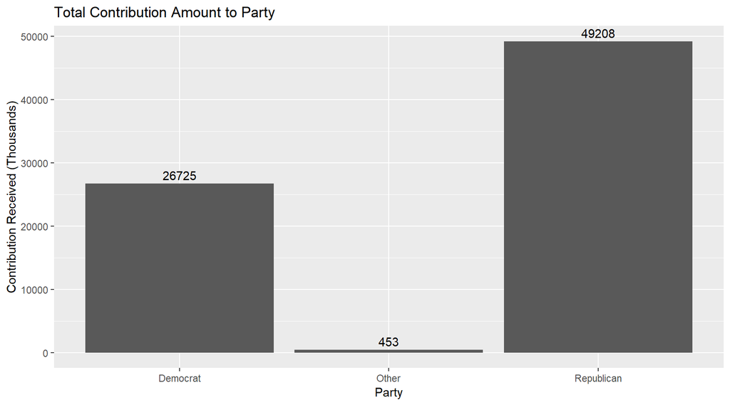

```
## tx$party: Democrat
##    Min. 1st Qu.  Median    Mean 3rd Qu.    Max.
##    0.04   11.00   25.00   93.51   50.00 2700.00
## --------------------------------------------------------
## tx$party: Other
##    Min. 1st Qu.  Median    Mean 3rd Qu.    Max.
##     2.0    50.0   100.0   240.9   250.0  2700.0
## --------------------------------------------------------
## tx$party: Republican
##    Min. 1st Qu.  Median    Mean 3rd Qu.    Max.
##     0.5    28.0    50.0   194.1   100.0  2700.0
```

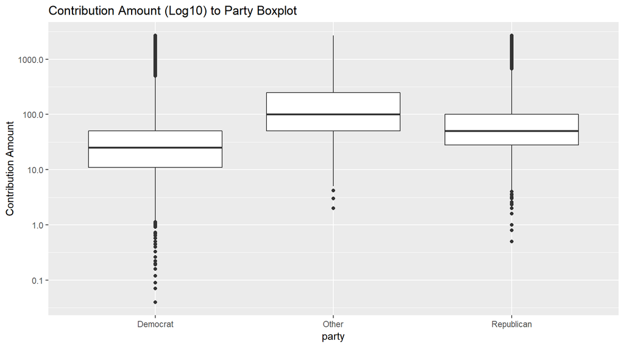

**FINDINGS**  
The Republican Parties mean and median contributions were higher than the Democratic Parties. You can also see from the boxplot above that the other parties mean and median was higher than both Republicans and Democrats.

## 2. Contribution Amount and Canidate (Bivariate)

```
## # A tibble: 25 x 5
## # Groups:   party [3]
##    party      cand_nm                  sum_can mean_can     n
##    <chr>      <fct>                      <dbl>    <dbl> <int>
##  1 Republican Pataki, George E.          6000      667.     9
##  2 Republican Gilmore, James S III      11800     2360      5
##  3 Democrat   Lessig, Lawrence          20028.     646.    31
##  4 Democrat   Webb, James Henry Jr.     31090.     545.    57
##  5 Other      McMullin, Evan            37237      195.   191
##  6 Republican Jindal, Bobby             42460      772     55
##  7 Other      Stein, Jill               86921.     259.   336
##  8 Democrat   O'Malley, Martin Joseph  139187      669.   208
##  9 Republican Graham, Lindsey O.       146487      997.   147
## 10 Republican Christie, Christopher J. 269355     1433.   188
## # ... with 15 more rows
```

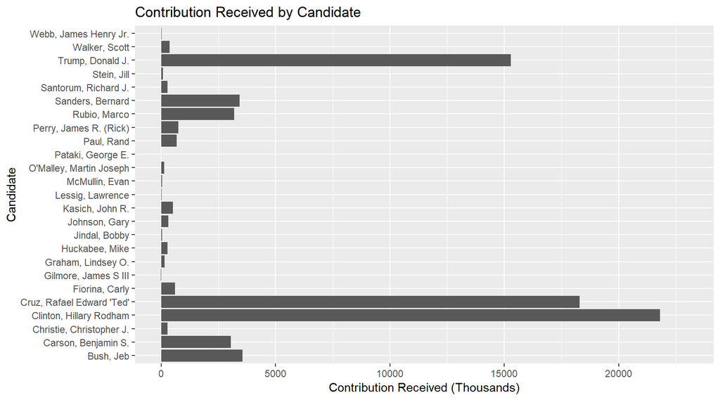

**FINDINGS**  
The canidates that recieved the most contributions were:  
- H. Clinton totaled approximately $21.8 million  
- T. Cruz totaled approximately $18.3 million  
- D. Trump totaled approximately $15.3 million  
- J. Bush totaled approximately $3.6 million  
- B. Sanders totaled approximately $3.4 million

```
## tx$cand_nm: Bush, Jeb
##    Min. 1st Qu.  Median    Mean 3rd Qu.    Max.
##       1     100     500    1127    2700    2700
## --------------------------------------------------------
## tx$cand_nm: Carson, Benjamin S.
##    Min. 1st Qu.  Median    Mean 3rd Qu.    Max.
##     0.5    25.0    50.0   135.7   100.0  2700.0
## --------------------------------------------------------
## tx$cand_nm: Christie, Christopher J.
##    Min. 1st Qu.  Median    Mean 3rd Qu.    Max.
##      10     100    1000    1433    2700    2700
## --------------------------------------------------------
## tx$cand_nm: Clinton, Hillary Rodham
##    Min. 1st Qu.  Median    Mean 3rd Qu.    Max.
##    0.04   11.00   25.00  112.20   75.00 2700.00
## --------------------------------------------------------
## tx$cand_nm: Cruz, Rafael Edward 'Ted'
##    Min. 1st Qu.  Median    Mean 3rd Qu.    Max.
##       1      25      50     143     100    2700
## --------------------------------------------------------
## tx$cand_nm: Fiorina, Carly
##    Min. 1st Qu.  Median    Mean 3rd Qu.    Max.
##     2.0    50.0   100.0   249.0   232.2  2700.0
## --------------------------------------------------------
## tx$cand_nm: Gilmore, James S III
##    Min. 1st Qu.  Median    Mean 3rd Qu.    Max.
##    1000    2700    2700    2360    2700    2700
## --------------------------------------------------------
## tx$cand_nm: Graham, Lindsey O.
##    Min. 1st Qu.  Median    Mean 3rd Qu.    Max.
##    10.0   250.0   500.0   996.5  1250.0  2700.0
## --------------------------------------------------------
## tx$cand_nm: Huckabee, Mike
##    Min. 1st Qu.  Median    Mean 3rd Qu.    Max.
##       1      35     100     404     500    2700
## --------------------------------------------------------
## tx$cand_nm: Jindal, Bobby
##    Min. 1st Qu.  Median    Mean 3rd Qu.    Max.
##      28     100     250     772    1000    2700
## --------------------------------------------------------
```

[output cut: 44 more lines]

```
## tx$cand_nm: Stein, Jill
##    Min. 1st Qu.  Median    Mean 3rd Qu.    Max.
##     4.2    50.0   100.0   258.7   250.0  2700.0
## --------------------------------------------------------
## tx$cand_nm: Trump, Donald J.
##    Min. 1st Qu.  Median    Mean 3rd Qu.    Max.
##     0.8    32.0    80.0   208.2   200.0  2700.0
## --------------------------------------------------------
## tx$cand_nm: Walker, Scott
##    Min. 1st Qu.  Median    Mean 3rd Qu.    Max.
##     5.0   250.0   500.0   879.9  1000.0  2700.0
## --------------------------------------------------------
## tx$cand_nm: Webb, James Henry Jr.
##    Min. 1st Qu.  Median    Mean 3rd Qu.    Max.
##    20.0   100.0   500.0   545.4   500.0  2700.0
```

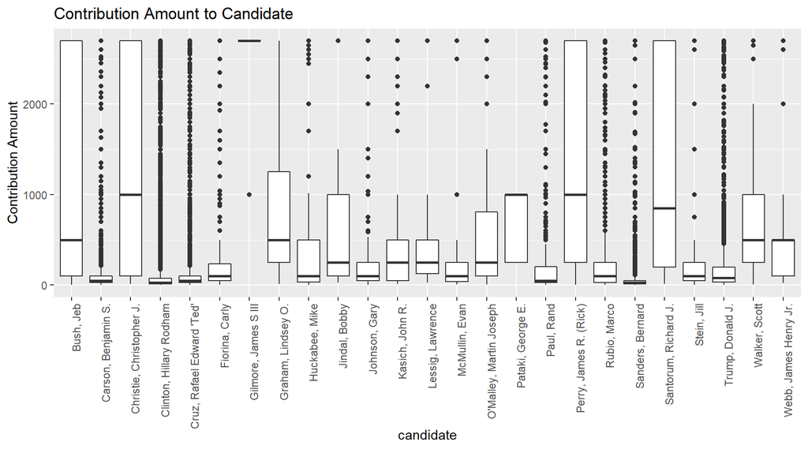

## 3. Contribution Amount by Gender (Bivariate)

```
## tx$gender: female
##    Min. 1st Qu.  Median    Mean 3rd Qu.    Max.
##    0.04   19.00   35.00  119.44   92.18 2700.00
## --------------------------------------------------------
## tx$gender: male
##    Min. 1st Qu.  Median    Mean 3rd Qu.    Max.
##    0.12   25.00   50.00  160.96  100.00 2700.00
```

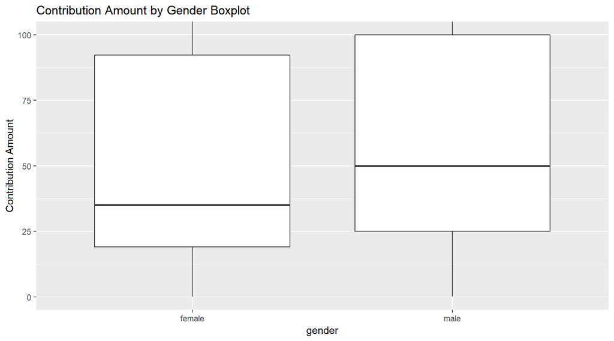

**Findings** By looking at the box plot and summary statistics above you can see the following differences between female and males: - the median contribution of males at $50.00 was higher than females the median contributions at $35.00. - males also had a higher average contribution amount of 160.96 compared to females at $119.44. This is a difference of $41.52.

## 4. Contribution Amount by Occupation (Bivariate)

```
## # A tibble: 5 x 4
##   contbr_occupation  sum_occu mean_occu      n
##   <ord>                 <dbl>     <dbl>  <int>
## 1 RETIRED           14463581.     106.  135939
## 2 NOT EMPLOYED       1115696.      49.3  22635
## 3 ATTORNEY           3970684.     294.   13516
## 4 HOMEMAKER          3396749.     328.   10358
## 5 ENGINEER           1178076.     139.    8484
```

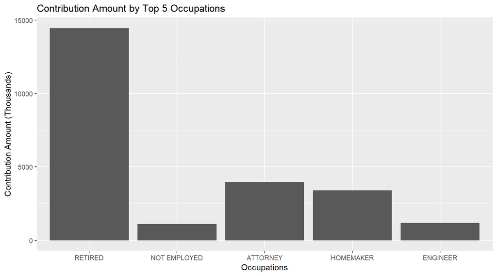

**FINDINGS**  
The occupation that contributed the highest amount was retired people contributing over $14.5 million. This was followed by:  
- Attorney at $3,970,684  
- Homemaker at $3,396,749  
- Engineer at $1,178,076  
- Not Employed at $1,115,696

# Bivariate Analysis

### Talk about some of the relationships you observed in this part of the

### investigation. How did the feature(s) of interest vary with other features

### in the dataset?

**Canidate**  
Even though Donald Trump was the Republican party nomination, Ted Cruz raised more money in Texas. This might be due to the fact that Ted Cruz was a Texas Senator when the election took place.

**Contributor Gender**  
Males accounted for more contributions and contributed larger amounts than females.

**Contributor Occupation**  
Retired people accounted for the most contributors by occupation.

### What was the strongest relationship you found?

Males accounted for more contributions and contributed larger amounts than females.

# Multivariate Plots Section

## 1. Contribution amounts by Canidate and Date (Multivariate)

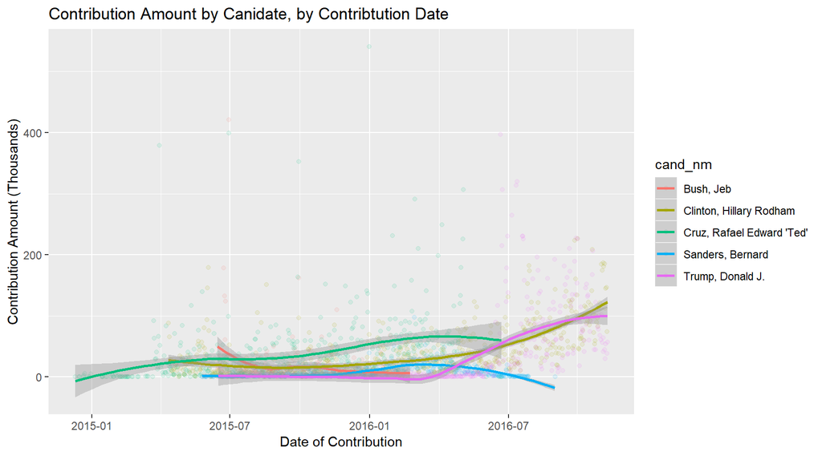

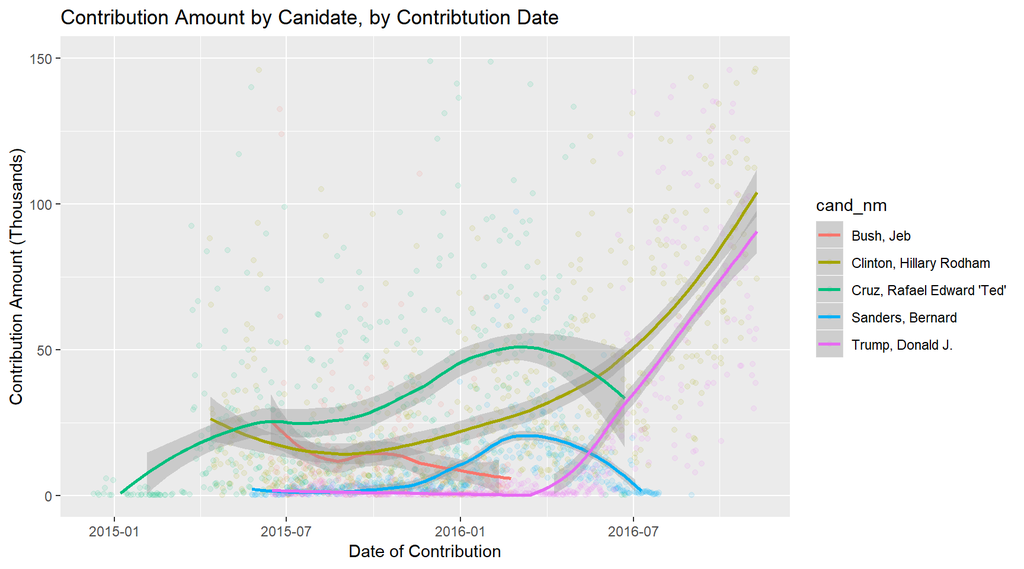

## 2. Contribution amounts by Occupation and Date (Multivariate)

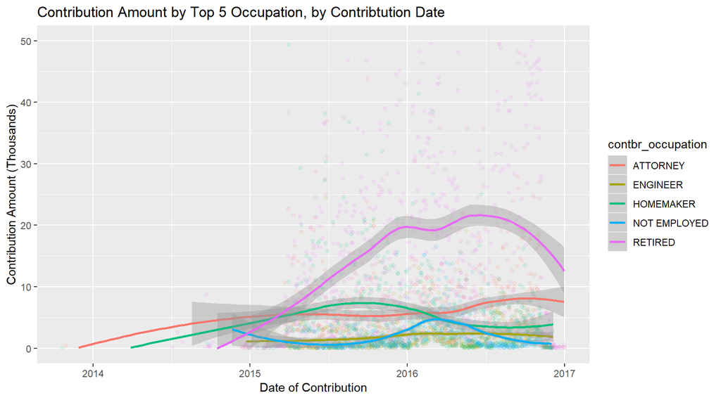

**FINDINGS**  
**Retired**  
- Most contributions began coming in towards the end of 2014  
- Contributions spiked towards the end of 2015, leveled off, and then began to increase towards the middle of 2016

**Attorney**  
- Contributions stayed steady throughout the general election period, but began to increase around July 2016

**Engineer**  
- Contributions stayed steady throughout the general election.

**Not Employed**  
- Contributions spiked and began to steadily decline starting around March 2016

# Multivariate Analysis

### Talk about some of the relationships you observed in this part of the

### investigation. Were there features that strengthened each other in terms of

### looking at your feature(s) of interest?

By adding the date the contribution was received I was able to see when the contributions came in and how the amounts compared between candidates and occupations.

It was also noticeable that retired people overtook all other occupations in the amount contributed starting around March 2015 and continued to contribute the all the way up to the general election.

### Were there any interesting or surprising interactions between features?

- Ted Cruz receiving contributions in January of 2015, the next canidate began receiving contributions around March 2015.

# Final Plots and Summary

### Plot One - Contribution Amount by Gender

```
## tx$gender: female
##    Min. 1st Qu.  Median    Mean 3rd Qu.    Max.
##    0.04   19.00   35.00  119.44   92.18 2700.00
## --------------------------------------------------------
## tx$gender: male
##    Min. 1st Qu.  Median    Mean 3rd Qu.    Max.
##    0.12   25.00   50.00  160.96  100.00 2700.00
```

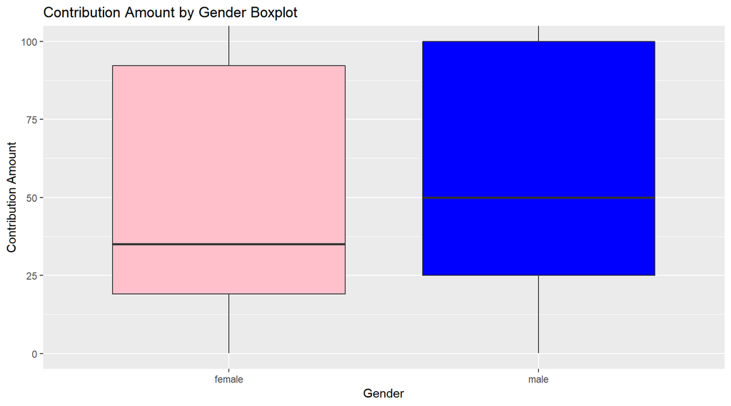

### Description One - Contribution Amount by Gender

I chose the Contribution Amount by Gender Box Plot because it shows there is a relationship between the persons gender and the contributions being made.

What I discovered was:  
- the median contribution of males at $50.00 was higher than females the median contributions at $35.00.  
- males also had a higher average contribution amount of 160.96 compared to females at $119.44. This is a difference of $41.52.

### Plot Two - Contribution Amount by Top 5 Occupations

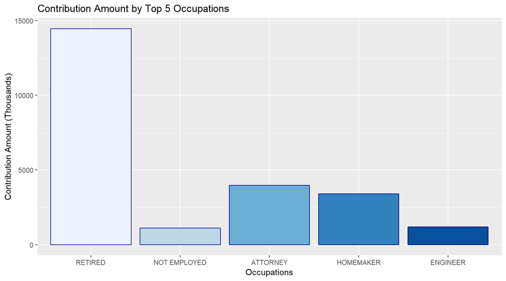

### Description Two - Contribution Amount by Top 5 Occupations

I chose the Contribution Amount by Top 5 Occupations because it shows the relationship between the top five occupations. It was interesting to see that retirees total contributions of over $14.5 million was more than the the other top four occupations combined at over $9.6 million.

### Plot Three - Contribution Amount by Canidate, by Contribtution Date

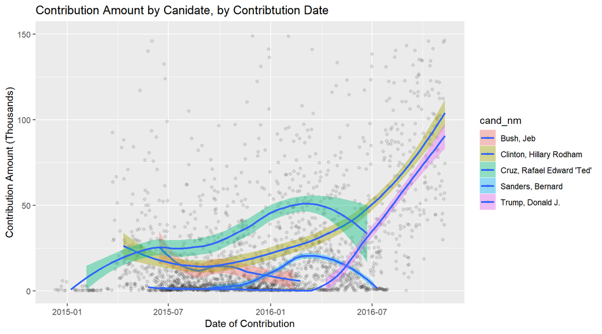

### Description Three - Contribution Amount by Canidate, by Contribtution Date

I chose the Contribution Amount by Canidate, by Contribtution Date because it shows the relationship between the top five canidates that received the highest contribution amounts. By adding the date of contribution to the analysis I was able to determine how much and when the contributions were received.

# Reflection

I was able to find relationships between:  
- number of contributions and party affiliation  
- number of contributions and presidential canidate  
- number of contributions and contributor gender  
- number of contributions and contributor occupation  
- contributions amounts and party affiliation  
- contributions amounts and presidential canidate  
- contributions amounts and contributor gender - contributions amounts and top five contributor occupations  
- contributions amounts, top five presidential canidate, and contribution date  
- contributions amounts, top five occupations, and contribution date

The dataset did not contain information that I felt was usefull to get a more detailed analysis. I wanted to know if gender played a part in the 2016 Presidential Election, so I created a gender column by taking e contributors first name (contbr_first_nm), created a gender dataset (gender_df) to create the column. I first tried installing and using the gender library, but found out I needed to use the library `genderdata`. The library genderdata is not available from a CRAN repository for the latest version of R. To install it, I used:  
`library(remotes)`  
`install_github("ropensci/genderdata")`

Since there were 16,992 different occupations listed in the data set I decided to only analyze the top five contributor occupations.

I removed the 10,093 contributions that were greater than the $2,700 because they should have been refunded.

I also removed the 12,084 contributions that were less than zero to get a better idea of what the contributions look liked.

## Future Work

Hopefully, I will come back to this project and do this part of the analysis.

## Additional Resources

N/A